# Assignment 4

Elliot Gavrin

2023-01-30

https://github.com/19eag3/BIOL432_Assignment4

Part 1 – Explore the data

```r
MyData <-read.csv("C:/Users/egavr/OneDrive/Documents/BIOL432/Csv files/Cohen_CANCERSEEK_liquid_biopsy_2018_modified.csv")
library(randomForest)
library(tree)
library(dplyr)
library(gbm)
dim(MyData)
```

```
## [1] 1804   42
```

```r
head(MyData)
```

```
##   Patient_ID     Sample_ID Tumor_type      AFP Angiopoietin_2     AXL CA_125
## 1    CRC 455 CRC 455 PLS 1 Colorectum 1583.450        5598.50 3621.04  5.090
## 2    CRC 456 CRC 456 PLS 1 Colorectum  715.308       20936.35 2772.96  7.270
## 3    CRC 457 CRC 457 PLS 1 Colorectum 4365.530        2350.93 4120.77  4.854
## 4    CRC 458 CRC 458 PLS 1 Colorectum  715.308        1604.34 2029.96  5.390
## 5    CRC 459 CRC 459 PLS 1 Colorectum  801.300        2087.57 2069.17  4.854
## 6    CRC 460 CRC 460 PLS 1 Colorectum  715.308        1147.55 2054.90  4.854
##   CA_15_3 CA19_9  CD44    CEA CYFRA_21_1 DKK1 Endoglin   FGF2 Follistatin
## 1   19.08 16.452  9.81  540.1   1938.654 0.78  2882.65  92.02     2144.33
## 2   10.04 40.910 27.57 5902.4   1938.654 0.77  3921.77 164.06     1646.26
## 3   16.96 16.452 14.59  973.8   1976.940 0.90  2410.16 154.77     2486.88
## 4    8.31 16.452  7.78 2027.5   1938.654 0.64  1284.96 227.57      829.43
## 5   11.73 16.452 12.21  614.5   1938.654 0.78  2552.72 134.72     2168.23
## 6    5.49 39.510  6.97 1242.3   1938.654 0.75  2459.50 123.75     1341.11
##   Galectin_3  G_CSF GDF15      HE4    HGF   IL_6   IL_8 Kallikrein_6    Leptin
```

[output cut: 27 more lines]

```r
tail(MyData)
```

```
##      Patient_ID       Sample_ID Tumor_type      AFP Angiopoietin_2     AXL
## 1799  PAPA 1353 PAPA 1353 PLS 1      Ovary  879.498        1484.70 2096.76
## 1800  PAPA 1354 PAPA 1354 PLS 1      Ovary 1337.330        1607.90  852.37
## 1801  PAPA 1355 PAPA 1355 PLS 1      Ovary  879.498        1592.84 1044.45
## 1802  PAPA 1356 PAPA 1356 PLS 1      Ovary  879.498        5267.95 1445.69
## 1803  PAPA 1357 PAPA 1357 PLS 1      Ovary  879.498        3546.43 1493.32
## 1804    LCR 620   LCR 9999 PLS1     Normal       NA             NA      NA
##       CA_125 CA_15_3 CA19_9  CD44     CEA CYFRA_21_1 DKK1 Endoglin   FGF2
## 1799   24.82   10.30  42.39 14.92  914.00   1970.916 3.05  1113.68 221.80
## 1800    5.58    9.80  16.44 12.32 1179.50   1970.916 1.74  1702.42 234.20
## 1801   30.48    8.48  16.44  8.26  443.01   3590.000 0.73   499.81  91.06
## 1802 1469.45   23.74  62.26 16.53  443.01  50659.050 1.24  2219.60 143.09
## 1803 1428.31  836.85  37.90 13.78  443.01   3060.000 1.01  1750.98 208.62
## 1804      NA      NA     NA    NA  548.73   2006.880 1.23   851.78 183.67
##      Follistatin Galectin_3   G_CSF GDF15       HE4     HGF  IL_6   IL_8
```

[output cut: 27 more lines]

```r
str(MyData)
```

```
## 'data.frame':    1804 obs. of  42 variables:
##  $ Patient_ID         : chr  "CRC 455" "CRC 456" "CRC 457" "CRC 458" ...
##  $ Sample_ID          : chr  "CRC 455 PLS 1" "CRC 456 PLS 1" "CRC 457 PLS 1" "CRC 458 PLS 1" ...
##  $ Tumor_type         : chr  "Colorectum" "Colorectum" "Colorectum" "Colorectum" ...
##  $ AFP                : num  1583 715 4366 715 801 ...
##  $ Angiopoietin_2     : num  5598 20936 2351 1604 2088 ...
##  $ AXL                : num  3621 2773 4121 2030 2069 ...
##  $ CA_125             : num  5.09 7.27 4.85 5.39 4.85 ...
##  $ CA_15_3            : num  19.08 10.04 16.96 8.31 11.73 ...
##  $ CA19_9             : num  16.5 40.9 16.5 16.5 16.5 ...
##  $ CD44               : num  9.81 27.57 14.59 7.78 12.21 ...
##  $ CEA                : num  540 5902 974 2028 614 ...
##  $ CYFRA_21_1         : num  1939 1939 1977 1939 1939 ...
##  $ DKK1               : num  0.78 0.77 0.9 0.64 0.78 0.75 0.86 0.71 0.59 0.64 ...
##  $ Endoglin           : num  2883 3922 2410 1285 2553 ...
```

[output cut: 28 more lines]

```r
summary(MyData)
```

```
##   Patient_ID         Sample_ID          Tumor_type             AFP
##  Length:1804        Length:1804        Length:1804        Min.   :   706.2
##  Class :character   Class :character   Class :character   1st Qu.:   833.7
##  Mode  :character   Mode  :character   Mode  :character   Median :   946.9
##                                                           Mean   :  7155.7
##                                                           3rd Qu.:  1855.0
##                                                           Max.   :600608.9
##                                                           NA's   :1
##  Angiopoietin_2          AXL              CA_125            CA_15_3
##  Min.   :   38.39   Min.   :  109.4   Min.   :   4.608   Min.   :   1.32
##  1st Qu.:  999.84   1st Qu.: 1476.8   1st Qu.:   4.890   1st Qu.:   7.11
##  Median : 1498.92   Median : 2136.6   Median :   4.980   Median :  12.20
##  Mean   : 1912.29   Mean   : 2367.6   Mean   :  25.326   Mean   :  20.71
##  3rd Qu.: 2266.73   3rd Qu.: 2934.3   3rd Qu.:   6.400   3rd Qu.:  19.86
##  Max.   :30001.79   Max.   :12247.3   Max.   :3600.024   Max.   :1177.45
##  NA's   :1          NA's   :1         NA's   :1          NA's   :1
##      CA19_9              CD44             CEA             CYFRA_21_1
##  Min.   :   14.21   Min.   :  6.75   Min.   :   426.4   Min.   :   1816
##  1st Qu.:   16.32   1st Qu.: 11.96   1st Qu.:   617.5   1st Qu.:   1955
##  Median :   16.48   Median : 16.73   Median :  1048.7   Median :   1995
##  Mean   :   54.11   Mean   : 19.53   Mean   :  4452.0   Mean   :   4861
##  3rd Qu.:   18.62   3rd Qu.: 23.77   3rd Qu.:  1935.1   3rd Qu.:   2107
##  Max.   :12491.47   Max.   :148.44   Max.   :337245.4   Max.   :1475728
##  NA's   :1          NA's   :1
##       DKK1          Endoglin             FGF2         Follistatin
##  Min.   :0.350   Min.   :   79.05   Min.   : 80.27   Min.   :  62.22
##  1st Qu.:0.740   1st Qu.: 1128.38   1st Qu.: 91.50   1st Qu.: 487.89
##  Median :0.940   Median : 1604.80   Median :117.53   Median : 769.02
##  Mean   :1.052   Mean   : 1674.69   Mean   :142.10   Mean   : 889.14
##  3rd Qu.:1.260   3rd Qu.: 2071.58   3rd Qu.:174.27   3rd Qu.:1101.48
##  Max.   :5.970   Max.   :16244.26   Max.   :734.55   Max.   :8126.49
##
##    Galectin_3          G_CSF              GDF15              HE4
##  Min.   :  0.200   Min.   :   29.48   Min.   : 0.0400   Min.   :  3672
##  1st Qu.:  4.308   1st Qu.:   38.50   1st Qu.: 0.2475   1st Qu.:  3997
##  Median :  5.860   Median :  115.65   Median : 0.4600   Median :  4093
##  Mean   :  7.959   Mean   :  195.29   Mean   : 0.7252   Mean   :  5628
##  3rd Qu.:  8.322   3rd Qu.:  186.80   3rd Qu.: 0.8425   3rd Qu.:  4209
##  Max.   :140.430   Max.   :12827.98   Max.   :24.2900   Max.   :189498
##
```

[output cut: 33 more lines]

```
##  Min.   :   306.3    Min.   :  219.8   Min.   :   15.26   Min.   :   482.1
##  1st Qu.:  4231.8    1st Qu.: 4386.1   1st Qu.:   16.23   1st Qu.:  1105.3
##  Median :  5259.8    Median : 5491.4   Median :   16.49   Median :  2245.7
##  Mean   :  5767.4    Mean   : 5881.7   Mean   :   28.20   Mean   :  5496.6
##  3rd Qu.:  6474.6    3rd Qu.: 7023.0   3rd Qu.:   16.70   3rd Qu.:  5662.7
##  Max.   :150848.1    Max.   :20178.2   Max.   :12018.86   Max.   :157461.1
##
##      TIMP_1             TIMP_2
##  Min.   :   976.5   Min.   : 15026
##  1st Qu.: 41217.9   1st Qu.: 30719
##  Median : 59293.3   Median : 37717
##  Mean   : 70144.0   Mean   : 40236
##  3rd Qu.: 83157.6   3rd Qu.: 46702
##  Max.   :569512.7   Max.   :105749
##
```

There are missing data is columns “AFP”, “Angiopoietin_2”, “AXL”, “CA_125”, “CA_15_3”, “CA19_9”, “CD44”. We can predict missing data with rfImpute(). It is not necessary to normalize the data for a Random Forest model because the model subsamples features and combines them. In other model types, you would need to normalize data to compare many features for a single model.

```r
#Identify if any columns have missing values
impFeatures <-names(
  MyData[,colSums(is.na(MyData))>0]
)
print(impFeatures)
```

```
## [1] "AFP"            "Angiopoietin_2" "AXL"            "CA_125"
## [5] "CA_15_3"        "CA19_9"         "CD44"
```

```r
colSums(is.na(MyData)) #There are not a lot of missing values per column. Therefore we can add our own data with rfImpute()
```

```
##          Patient_ID           Sample_ID          Tumor_type                 AFP
##                   0                   0                   0                   1
##      Angiopoietin_2                 AXL              CA_125             CA_15_3
##                   1                   1                   1                   1
##              CA19_9                CD44                 CEA          CYFRA_21_1
##                   1                   1                   0                   0
##                DKK1            Endoglin                FGF2         Follistatin
##                   0                   0                   0                   0
##          Galectin_3               G_CSF               GDF15                 HE4
##                   0                   0                   0                   0
##                 HGF                IL_6                IL_8        Kallikrein_6
##                   0                   0                   0                   0
##              Leptin          Mesothelin             Midkine     Myeloperoxidase
##                   0                   0                   0                   0
##                 NSE                 OPG                 OPN                 PAR
##                   0                   0                   0                   0
##           Prolactin               sEGFR                sFas                SHBG
##                   0                   0                   0                   0
## sHER2_sEGFR2_sErbB2            sPECAM_1                TGFa    Thrombospondin_2
##                   0                   0                   0                   0
##              TIMP_1              TIMP_2
##                   0                   0
```

```r
dim(MyData)
```

```
## [1] 1804   42
```

```r
impFeatures<-c("AFP", "Angiopoietin_2", "AXL", "CA_125", "CA_15_3", "CA19_9", "CD44")
Imputed <-rfImpute(x=MyData[,impFeatures],
                   y=as.factor(MyData$Tumor_type))
```

```
## ntree      OOB      1      2      3      4      5      6      7      8      9
##   300:  29.93% 59.62% 28.61%100.00% 75.00% 73.08%  5.38% 33.33% 33.33% 86.76%
## ntree      OOB      1      2      3      4      5      6      7      8      9
##   300:  30.04% 60.58% 28.87%100.00% 65.91% 77.88%  5.25% 33.33% 32.26% 86.76%
## ntree      OOB      1      2      3      4      5      6      7      8      9
##   300:  29.16% 54.81% 27.58%100.00% 77.27% 74.04%  5.88% 31.48% 30.11% 83.82%
## ntree      OOB      1      2      3      4      5      6      7      8      9
##   300:  30.04% 58.65% 29.38%100.00% 68.18% 74.04%  5.50% 33.33% 36.56% 85.29%
## ntree      OOB      1      2      3      4      5      6      7      8      9
##   300:  30.04% 59.13% 28.09%100.00% 75.00% 78.85%  5.62% 33.33% 32.26% 83.82%
```

```r
head(Imputed)
```

```
##   as.factor(MyData$Tumor_type)      AFP Angiopoietin_2     AXL CA_125 CA_15_3
## 1                   Colorectum 1583.450        5598.50 3621.04  5.090   19.08
## 2                   Colorectum  715.308       20936.35 2772.96  7.270   10.04
## 3                   Colorectum 4365.530        2350.93 4120.77  4.854   16.96
## 4                   Colorectum  715.308        1604.34 2029.96  5.390    8.31
## 5                   Colorectum  801.300        2087.57 2069.17  4.854   11.73
## 6                   Colorectum  715.308        1147.55 2054.90  4.854    5.49
##   CA19_9  CD44
## 1 16.452  9.81
## 2 40.910 27.57
## 3 16.452 14.59
## 4 16.452  7.78
## 5 16.452 12.21
## 6 39.510  6.97
```

```r
dim(Imputed)
```

```
## [1] 1804    8
```

```r
FullData <-MyData
FullData[,impFeatures]<-Imputed[,impFeatures]
colSums(is.na(FullData)) #each column sum = 0
```

```
##          Patient_ID           Sample_ID          Tumor_type                 AFP
##                   0                   0                   0                   0
##      Angiopoietin_2                 AXL              CA_125             CA_15_3
##                   0                   0                   0                   0
##              CA19_9                CD44                 CEA          CYFRA_21_1
##                   0                   0                   0                   0
##                DKK1            Endoglin                FGF2         Follistatin
##                   0                   0                   0                   0
##          Galectin_3               G_CSF               GDF15                 HE4
##                   0                   0                   0                   0
##                 HGF                IL_6                IL_8        Kallikrein_6
##                   0                   0                   0                   0
##              Leptin          Mesothelin             Midkine     Myeloperoxidase
##                   0                   0                   0                   0
##                 NSE                 OPG                 OPN                 PAR
##                   0                   0                   0                   0
##           Prolactin               sEGFR                sFas                SHBG
##                   0                   0                   0                   0
## sHER2_sEGFR2_sErbB2            sPECAM_1                TGFa    Thrombospondin_2
##                   0                   0                   0                   0
##              TIMP_1              TIMP_2
##                   0                   0
```

There are 800 normal samples and 1004 tumor samples.

```r
dim(FullData)
```

```
## [1] 1804   42
```

```r
table(FullData$Tumor_type)
```

```
##
##     Breast Colorectum  Esophagus      Liver       Lung     Normal      Ovary
##        208        388         45         44        104        800         54
##   Pancreas    Stomach
##         93         68
```

```r
Train <-c(1:nrow(FullData)) %% 2
Validate <-1-Train
```

Part 2 – Decision tree

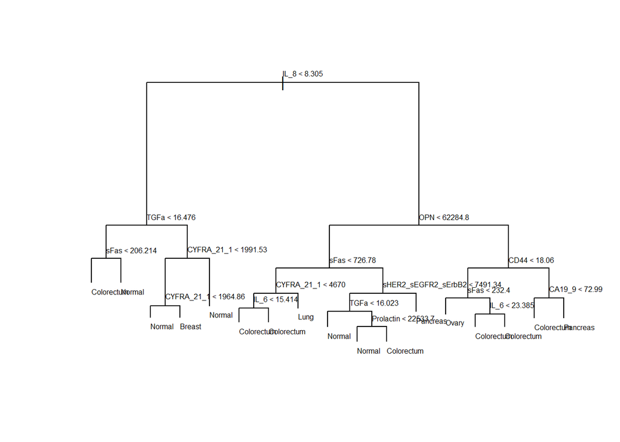

```r
FullData <-FullData %>%
  select(-c("Patient_ID", "Sample_ID"))
FullData <-FullData %>%
  mutate(Tumor_type=as.factor(Tumor_type))
TumorTree <-tree::tree(Tumor_type ~ ., data=FullData)
plot(TumorTree); text(TumorTree, cex=0.5, adj=0)
```

IL_8 was the protein feature most influential for classifying samples, as it is the root of the tree. Its longer branches indicate that it had the post predictions that classify more of the observations.

```r
CatDat <-data.frame(Obs=FullData$Tumor_type,Pred=predict(TumorTree, FullData, type="class"))
table(CatDat)
```

```
##             Pred
## Obs          Breast Colorectum Esophagus Liver Lung Normal Ovary Pancreas
##   Breast         54         71         0     0   12     63     1        7
##   Colorectum      2        312         0     0   13     39    18        4
##   Esophagus       7         32         0     0    0      5     1        0
##   Liver           0         40         0     0    0      2     1        1
##   Lung           17         56         0     0   18     10     3        0
##   Normal          5         71         0     0    0    711     0       13
##   Ovary           9         13         0     0    9      1    19        3
##   Pancreas        0         29         0     0    0      7     0       57
##   Stomach         3         52         0     0    3      9     1        0
##             Pred
## Obs          Stomach
##   Breast           0
##   Colorectum       0
##   Esophagus        0
##   Liver            0
##   Lung             0
##   Normal           0
##   Ovary            0
##   Pancreas         0
##   Stomach          0
```

```r
head(CatDat)
```

```
##          Obs       Pred
## 1 Colorectum Colorectum
## 2 Colorectum Colorectum
## 3 Colorectum      Ovary
## 4 Colorectum Colorectum
## 5 Colorectum Colorectum
## 6 Colorectum      Ovary
```

```r
summary(TumorTree)
```

```
##
## Classification tree:
## tree::tree(formula = Tumor_type ~ ., data = FullData)
## Variables actually used in tree construction:
##  [1] "IL_8"                "TGFa"                "sFas"
##  [4] "CYFRA_21_1"          "OPN"                 "IL_6"
##  [7] "sHER2_sEGFR2_sErbB2" "Prolactin"           "CD44"
## [10] "CA19_9"
## Number of terminal nodes:  17
## Residual mean deviance:  1.966 = 3513 / 1787
## Misclassification error rate: 0.3509 = 633 / 1804
```

```r
MisClass <-CatDat %>%
  filter(Obs!=Pred)
nrow(MisClass)/nrow(CatDat)
```

```
## [1] 0.3508869
```

Part 3 – Random Forest

```r
#Random Forest
TumorForest <-randomForest(Tumor_type ~ ., data=FullData, ntree=100, mtry=3,nodesize=5,importance=TRUE)
ForrestPred <-data.frame(Obs=FullData$Tumor_type,Pred=predict(TumorTree, FullData, type="class"))
table(ForrestPred)
```

```
##             Pred
## Obs          Breast Colorectum Esophagus Liver Lung Normal Ovary Pancreas
##   Breast         54         71         0     0   12     63     1        7
##   Colorectum      2        312         0     0   13     39    18        4
##   Esophagus       7         32         0     0    0      5     1        0
##   Liver           0         40         0     0    0      2     1        1
##   Lung           17         56         0     0   18     10     3        0
##   Normal          5         71         0     0    0    711     0       13
##   Ovary           9         13         0     0    9      1    19        3
##   Pancreas        0         29         0     0    0      7     0       57
##   Stomach         3         52         0     0    3      9     1        0
##             Pred
## Obs          Stomach
##   Breast           0
##   Colorectum       0
##   Esophagus        0
##   Liver            0
##   Lung             0
##   Normal           0
##   Ovary            0
##   Pancreas         0
##   Stomach          0
```

```r
print(TumorForest)
```

```
##
## Call:
##  randomForest(formula = Tumor_type ~ ., data = FullData, ntree = 100,      mtry = 3, nodesize = 5, importance = TRUE)
##                Type of random forest: classification
##                      Number of trees: 100
## No. of variables tried at each split: 3
##
##         OOB estimate of  error rate: 23.56%
## Confusion matrix:
##            Breast Colorectum Esophagus Liver Lung Normal Ovary Pancreas Stomach
## Breast        113         45         0     1    8     38     0        3       0
## Colorectum      9        347         1     0    4     21     0        3       3
## Esophagus       5         32         1     0    1      5     0        0       1
## Liver           3         25         1     6    1      3     0        3       2
## Lung           33         34         0     0   33      3     0        0       1
## Normal          3         11         0     0    0    784     0        2       0
## Ovary           7         11         0     0    1      3    31        1       0
## Pancreas        1         17         0     0    0     16     0       59       0
## Stomach         9         40         1     2    5      6     0        0       5
##            class.error
## Breast       0.4567308
## Colorectum   0.1056701
## Esophagus    0.9777778
## Liver        0.8636364
## Lung         0.6826923
## Normal       0.0200000
## Ovary        0.4259259
## Pancreas     0.3655914
## Stomach      0.9264706
```

```r
TumorForest$importance
```

```
##                            Breast    Colorectum     Esophagus         Liver
## AFP                  1.007356e-02  7.961876e-03  0.0008595102  0.0543220043
## Angiopoietin_2       3.537437e-03 -1.578702e-05  0.0029073318  0.0025227591
## AXL                  1.147340e-03  1.170737e-03 -0.0009013666  0.0037315699
## CA_125               5.904715e-03  1.326727e-02  0.0020980392 -0.0022761911
## CA_15_3             -1.844768e-03  1.592942e-02  0.0015902024  0.0042410725
## CA19_9               7.118027e-03  1.087987e-02  0.0004428230  0.0026036160
## CD44                 1.104522e-02  1.134171e-02  0.0041096306  0.0097712220
## CEA                  2.006435e-03  8.215451e-03  0.0015855862 -0.0054225200
## CYFRA_21_1           1.485404e-02  1.122955e-02  0.0030088004  0.0047310639
## DKK1                 3.632573e-03  1.176547e-02 -0.0016740939  0.0046467363
## Endoglin             2.075990e-03  1.912220e-04 -0.0001354489  0.0020728904
## FGF2                 5.512831e-03  3.423540e-03 -0.0043135204  0.0002006019
## Follistatin          3.021154e-03  4.071780e-03  0.0023328426 -0.0012872868
## Galectin_3          -1.622596e-03  3.356721e-03 -0.0002272402 -0.0025070627
## G_CSF                4.456642e-03  1.084075e-02  0.0041087050  0.0032137260
## GDF15                9.640374e-03  2.733049e-02  0.0124158290  0.0125742925
## HE4                  1.768735e-02  5.455148e-03  0.0120666095  0.0016972050
## HGF                  1.441895e-02  1.660453e-02  0.0096796316  0.0128989484
## IL_6                 3.142659e-02  2.868978e-02  0.0278696546  0.0226294291
## IL_8                 2.515604e-02  4.208044e-02  0.0334213525  0.0275680981
## Kallikrein_6         1.473726e-03  2.929975e-03  0.0021678025  0.0066802799
## Leptin               1.717731e-02  5.462133e-03  0.0037122633 -0.0033879145
## Mesothelin           8.220983e-05  4.092134e-04  0.0020628024  0.0017559807
## Midkine              1.368538e-02  7.438004e-03  0.0078532381 -0.0005050923
## Myeloperoxidase      8.220272e-03  5.114458e-03  0.0093463059  0.0188222388
## NSE                  1.271802e-02  1.447136e-02  0.0062360481  0.0039072175
## OPG                  7.008561e-03  6.570079e-03  0.0017038368  0.0047920084
## OPN                  4.409535e-03  1.652607e-02  0.0126150932  0.0285721584
## PAR                  9.018832e-03 -3.694830e-04 -0.0023670635 -0.0003511905
## Prolactin            9.164215e-03  1.133529e-02  0.0005346271  0.0043832621
## sEGFR                7.837249e-03  3.649840e-03  0.0009818197  0.0059019313
## sFas                 2.412639e-02  5.231504e-02  0.0035875110  0.0152465871
## SHBG                -3.452817e-05  4.903257e-03  0.0001875773  0.0045157024
## sHER2_sEGFR2_sErbB2  1.894775e-03  1.132858e-02  0.0029359468  0.0015657335
## sPECAM_1             3.186887e-03  1.311262e-03  0.0032378713  0.0012481447
## TGFa                 3.105689e-02  2.283269e-02  0.0066484188  0.0011630134
## Thrombospondin_2     6.826890e-03  1.188752e-02  0.0050297558  0.0212503893
## TIMP_1               7.141400e-03  6.401310e-03  0.0177775326  0.0052402552
## TIMP_2               1.242470e-02  8.459368e-03  0.0024133948  0.0019256536
```

[output cut: 65 more lines]

```
## Myeloperoxidase      0.0102769532         0.0110395339         26.39512
## NSE                  0.0006417033         0.0180008766         31.15320
## OPG                 -0.0002677790         0.0081696687         22.41863
## OPN                  0.0156817183         0.0224186657         53.91371
## PAR                  0.0018542484         0.0024157036         15.42476
## Prolactin            0.0023216917         0.0213256894         46.35897
## sEGFR                0.0101067406         0.0060655491         24.18094
## sFas                 0.0057695041         0.0317680565         44.26836
## SHBG                 0.0017821582         0.0018457204         14.76627
## sHER2_sEGFR2_sErbB2  0.0071188183         0.0105879086         28.77809
## sPECAM_1            -0.0005348084         0.0019556655         14.75901
## TGFa                 0.0134772483         0.0325807153         43.31740
## Thrombospondin_2     0.0037921218         0.0124373188         29.62279
## TIMP_1               0.0077021318         0.0092021028         22.70782
## TIMP_2              -0.0009793002         0.0103139058         25.19183
```

```r
ForrestBoost<-gbm(Tumor_type ~ ., data=FullData,
                  distribution="gaussian",
                  n.trees=25, interaction.depth=2, cv.folds=12)

print(ForrestBoost)
```

```
## gbm(formula = Tumor_type ~ ., distribution = "gaussian", data = FullData,
##     n.trees = 25, interaction.depth = 2, cv.folds = 12)
## A gradient boosted model with gaussian loss function.
## 25 iterations were performed.
## The best cross-validation iteration was 25.
## There were 39 predictors of which 15 had non-zero influence.
```

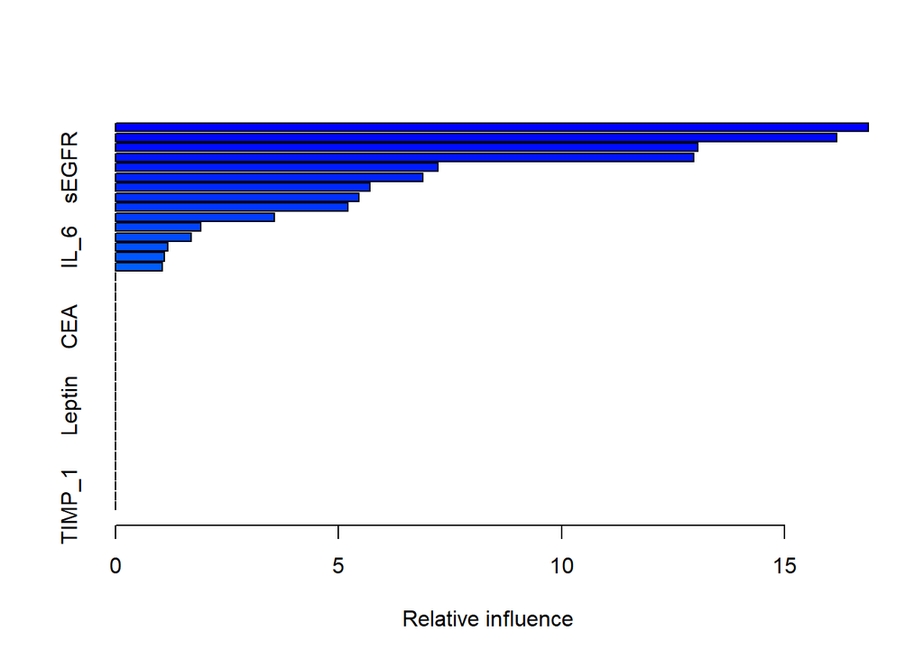

```
##                                     var   rel.inf
## TGFa                               TGFa 16.870938
## IL_8                               IL_8 16.162476
## TIMP_2                           TIMP_2 13.046097
## sFas                               sFas 12.953420
## sEGFR                             sEGFR  7.228695
## CA19_9                           CA19_9  6.887929
## HE4                                 HE4  5.706019
## HGF                                 HGF  5.448518
## Prolactin                     Prolactin  5.209316
## Thrombospondin_2       Thrombospondin_2  3.555778
## G_CSF                             G_CSF  1.915706
## CA_125                           CA_125  1.691844
## IL_6                               IL_6  1.178209
## sHER2_sEGFR2_sErbB2 sHER2_sEGFR2_sErbB2  1.092292
## Kallikrein_6               Kallikrein_6  1.052761
## AFP                                 AFP  0.000000
## Angiopoietin_2           Angiopoietin_2  0.000000
## AXL                                 AXL  0.000000
## CA_15_3                         CA_15_3  0.000000
## CD44                               CD44  0.000000
## CEA                                 CEA  0.000000
## CYFRA_21_1                   CYFRA_21_1  0.000000
## DKK1                               DKK1  0.000000
## Endoglin                       Endoglin  0.000000
## FGF2                               FGF2  0.000000
## Follistatin                 Follistatin  0.000000
## Galectin_3                   Galectin_3  0.000000
## GDF15                             GDF15  0.000000
## Leptin                           Leptin  0.000000
## Mesothelin                   Mesothelin  0.000000
## Midkine                         Midkine  0.000000
## Myeloperoxidase         Myeloperoxidase  0.000000
## NSE                                 NSE  0.000000
## OPG                                 OPG  0.000000
## OPN                                 OPN  0.000000
## PAR                                 PAR  0.000000
## SHBG                               SHBG  0.000000
## sPECAM_1                       sPECAM_1  0.000000
## TIMP_1                           TIMP_1  0.000000
```

```r
summary(ForrestBoost)
```

Lastly, create a new table where your dependent variable is cancer or normal. Combine all tumor types into ‘cancer’ and keep non-cancer samples as ‘normal’ in a column called ‘binary’. Again, make sure this is a factor and split this into training and test sets. Run another random forest model but this time use the ‘binary’ column as the response variable. Remember to include the importance = T flag.

```r
binary<-NA
binary[FullData$Tumor_type=="Normal"]<-"normal"
binary[FullData$Tumor_type!="Normal"]<-"cancer"
CNDat <-cbind(FullData, binary)

CNDat <-CNDat %>%
  mutate(binary=as.factor(binary))

CNTrain <-c(1:nrow(CNDat)) %% 2
CNValidate <-1-Train

CNForest <-randomForest(binary ~ ., data=CNDat, ntree=100, mtry=3,nodesize=5,importance=TRUE)
CNPred <-data.frame(Obs=CNDat$binary,Pred=predict(TumorTree, CNDat, type="class"))
table(ForrestPred)
```

```
##             Pred
## Obs          Breast Colorectum Esophagus Liver Lung Normal Ovary Pancreas
##   Breast         54         71         0     0   12     63     1        7
##   Colorectum      2        312         0     0   13     39    18        4
##   Esophagus       7         32         0     0    0      5     1        0
##   Liver           0         40         0     0    0      2     1        1
##   Lung           17         56         0     0   18     10     3        0
##   Normal          5         71         0     0    0    711     0       13
##   Ovary           9         13         0     0    9      1    19        3
##   Pancreas        0         29         0     0    0      7     0       57
##   Stomach         3         52         0     0    3      9     1        0
##             Pred
## Obs          Stomach
##   Breast           0
##   Colorectum       0
##   Esophagus        0
##   Liver            0
##   Lung             0
##   Normal           0
##   Ovary            0
##   Pancreas         0
##   Stomach          0
```

```r
print(CNForest)
```

```
##
## Call:
##  randomForest(formula = binary ~ ., data = CNDat, ntree = 100,      mtry = 3, nodesize = 5, importance = TRUE)
##                Type of random forest: classification
##                      Number of trees: 100
## No. of variables tried at each split: 3
##
##         OOB estimate of  error rate: 0.61%
## Confusion matrix:
##        cancer normal class.error
## cancer    999      5  0.00498008
## normal      6    794  0.00750000
```

```r
CNForest$importance
```

```
##                            cancer        normal MeanDecreaseAccuracy
## Tumor_type           1.874575e-01  2.101116e-01         1.970926e-01
## AFP                  6.234122e-03  5.277529e-03         5.788832e-03
## Angiopoietin_2       9.340952e-04  1.069820e-03         9.886023e-04
## AXL                  8.894767e-04  1.338370e-04         5.553511e-04
## CA_125               1.279236e-02  1.708349e-02         1.464108e-02
## CA_15_3              3.821381e-04  5.620133e-04         4.609919e-04
## CA19_9               1.063597e-02  1.204754e-02         1.122961e-02
## CD44                 2.337544e-03  1.803336e-03         2.069725e-03
## CEA                  2.125864e-03  7.265249e-03         4.376128e-03
## CYFRA_21_1           1.216305e-02  3.388176e-02         2.170576e-02
## DKK1                 2.063673e-03  2.910770e-03         2.440655e-03
## Endoglin            -4.084605e-05  1.674710e-04         4.566539e-05
## FGF2                 1.550623e-03  2.983753e-03         2.191860e-03
## Follistatin          3.861244e-04  5.357904e-04         4.567771e-04
## Galectin_3          -1.056889e-04  2.204626e-03         9.174160e-04
## G_CSF                6.093020e-03  5.328468e-03         5.778429e-03
## GDF15                1.588645e-02  2.147110e-02         1.830793e-02
## HE4                  5.289225e-03  1.242806e-02         8.438187e-03
## HGF                  9.496114e-03  2.144032e-02         1.470185e-02
## IL_6                 2.723525e-02  2.312877e-02         2.542938e-02
## IL_8                 2.834922e-02  2.056849e-02         2.498376e-02
## Kallikrein_6        -2.554820e-04  1.794203e-03         6.597215e-04
## Leptin               1.110144e-03 -4.597441e-06         6.247812e-04
## Mesothelin           7.186439e-04  5.770438e-04         6.671681e-04
## Midkine              2.023902e-03  4.680671e-03         3.180322e-03
## Myeloperoxidase      3.087782e-03  6.235138e-03         4.489377e-03
## NSE                  5.562351e-03  1.343274e-02         9.020098e-03
## OPG                  2.209520e-03  7.600622e-03         4.565413e-03
## OPN                  1.673853e-02  1.732420e-02         1.690098e-02
## PAR                  7.744775e-04  5.273290e-04         6.776718e-04
## Prolactin            4.959025e-03  1.770890e-02         1.060376e-02
## sEGFR                5.495979e-03  3.451004e-03         4.566555e-03
## sFas                 6.668018e-03  1.557804e-02         1.061111e-02
## SHBG                 1.073853e-03  1.625508e-04         6.700341e-04
## sHER2_sEGFR2_sErbB2  1.045058e-03  5.036521e-03         2.821243e-03
## sPECAM_1             8.734622e-04  9.705096e-04         9.121603e-04
## TGFa                 1.851871e-02  2.093943e-02         1.955878e-02
## Thrombospondin_2     4.523170e-03  8.926939e-03         6.454450e-03
## TIMP_1               6.110798e-03  3.388973e-03         4.885227e-03
```

[output cut: 27 more lines]

```
## Myeloperoxidase            10.123665
## NSE                        16.869714
## OPG                         8.135420
## OPN                        49.418118
## PAR                         3.429897
## Prolactin                  33.531549
## sEGFR                      21.654883
## sFas                       17.499066
## SHBG                        3.989567
## sHER2_sEGFR2_sErbB2         8.230100
## sPECAM_1                    4.118271
## TGFa                       27.946278
## Thrombospondin_2           10.831080
## TIMP_1                     12.721112
## TIMP_2                      6.619696
```

```r
BinaryBoost<-gbm(binary ~ ., data=CNDat,
                  distribution="gaussian",
                  n.trees=25, interaction.depth=2, cv.folds=12)

print(BinaryBoost)
```

```
## gbm(formula = binary ~ ., distribution = "gaussian", data = CNDat,
##     n.trees = 25, interaction.depth = 2, cv.folds = 12)
## A gradient boosted model with gaussian loss function.
## 25 iterations were performed.
## The best cross-validation iteration was 25.
## There were 40 predictors of which 10 had non-zero influence.
```

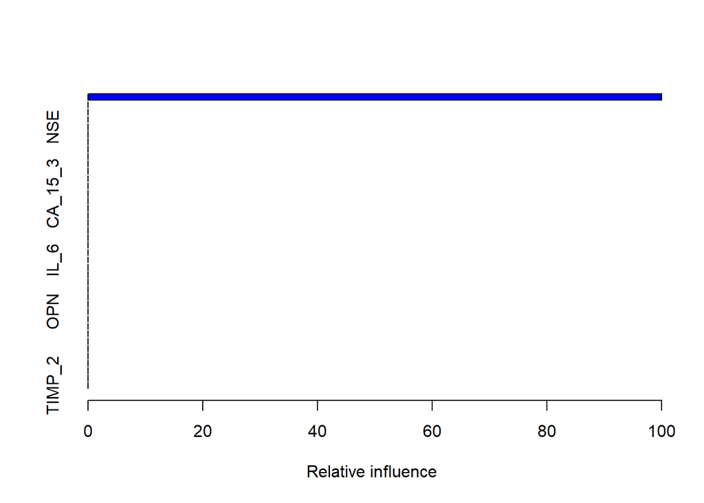

```
##                                     var      rel.inf
## Tumor_type                   Tumor_type 1.000000e+02
## AFP                                 AFP 1.618552e-25
## DKK1                               DKK1 1.068837e-26
## PAR                                 PAR 4.527979e-27
## NSE                                 NSE 2.360071e-27
## Galectin_3                   Galectin_3 1.459484e-27
## FGF2                               FGF2 1.088887e-27
## HGF                                 HGF 6.463215e-28
## GDF15                             GDF15 5.654786e-28
## Midkine                         Midkine 1.890546e-29
## Angiopoietin_2           Angiopoietin_2 0.000000e+00
## AXL                                 AXL 0.000000e+00
## CA_125                           CA_125 0.000000e+00
## CA_15_3                         CA_15_3 0.000000e+00
## CA19_9                           CA19_9 0.000000e+00
## CD44                               CD44 0.000000e+00
## CEA                                 CEA 0.000000e+00
## CYFRA_21_1                   CYFRA_21_1 0.000000e+00
## Endoglin                       Endoglin 0.000000e+00
## Follistatin                 Follistatin 0.000000e+00
## G_CSF                             G_CSF 0.000000e+00
## HE4                                 HE4 0.000000e+00
## IL_6                               IL_6 0.000000e+00
## IL_8                               IL_8 0.000000e+00
## Kallikrein_6               Kallikrein_6 0.000000e+00
## Leptin                           Leptin 0.000000e+00
## Mesothelin                   Mesothelin 0.000000e+00
## Myeloperoxidase         Myeloperoxidase 0.000000e+00
## OPG                                 OPG 0.000000e+00
## OPN                                 OPN 0.000000e+00
## Prolactin                     Prolactin 0.000000e+00
## sEGFR                             sEGFR 0.000000e+00
## sFas                               sFas 0.000000e+00
## SHBG                               SHBG 0.000000e+00
## sHER2_sEGFR2_sErbB2 sHER2_sEGFR2_sErbB2 0.000000e+00
## sPECAM_1                       sPECAM_1 0.000000e+00
## TGFa                               TGFa 0.000000e+00
## Thrombospondin_2       Thrombospondin_2 0.000000e+00
## TIMP_1                           TIMP_1 0.000000e+00
## TIMP_2                           TIMP_2 0.000000e+00
```

```r
summary(BinaryBoost)
```

These proteins are influential for classifying tumor and normal blood biopsies because they have identifiable structures that can be seen in spectroscopy. They also have unique shapes that can interact with metabolic pathways and influence pacemaker enzymes in the cell.

Random Forest models are useful for detecting cancer in blood samples as they are able to categorize proteins by their relative influence. This allows researchers to shift their focus to investigate proteins with the influence and prevalence in the datasheet towards cancer. Additionally, it is useful information to discover what proteins are essential for a healthy, normal cell.